# Prediction of the quality of the exercise from accelerometers readings

## Summary

In this report, we try to predict the quality of the exercise from different accelerometers readings. The accelerometers are placed on the belt, forearm, arm and dumbell. The six participants were asked to perform barbell lifts in 5 different ways, correctly and incorrectly. Prediction was done using random forest with **52** predictor and **25** repitions of bootstrapping. The prediction succeeded with out-of-sample estimate error rate of **0.83%**.

## Data

The data used in this report is from the Weight Lifting Exercises Dataset in the Human Activity Recognition (HAR) project (see References). Six young participants (20-28 years) were asked to perform barbell lifts in 5 different ways defined in classes (A, B, C, D, and E). Different readings were taken from accelerometers placed on the belt, forearm, arm and dumbell. The data consists of **19,622** records and **160** features.

## Data Cleaning

After removing the features with mostly NAs or missing values as well as the non-numeric features, we end up with 53 features instead of 160.

## Data Spliting

Next, the data was splitted into training (60% of the data) and testing sets. The training set consists of 11,776 records while the testing set consists of 7,846.

## Model Creation

```
##
## Call:
##  randomForest(x = x, y = y, mtry = param$mtry)
##                Type of random forest: classification
##                      Number of trees: 500
## No. of variables tried at each split: 27
##
##         OOB estimate of  error rate: 0.83%
## Confusion matrix:
##      A    B    C    D    E class.error
## A 3344    2    1    0    1    0.001195
## B   19 2250    9    1    0    0.012725
## C    0   12 2033    9    0    0.010224
## D    1    1   26 1898    4    0.016580
## E    0    2    5    5 2153    0.005543
```

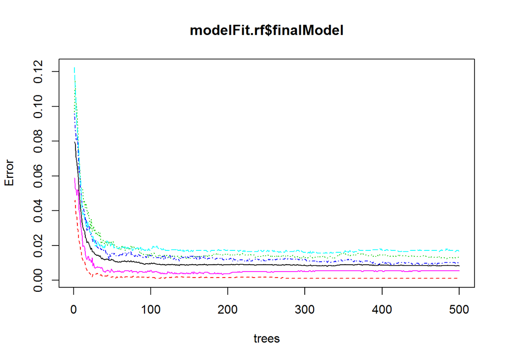

## Results

```
## Confusion Matrix and Statistics
##
##           Reference
## Prediction    A    B    C    D    E
##          A 2228   15    0    0    0
##          B    4 1492    7    0    2
##          C    0   11 1356   27    2
##          D    0    0    5 1257    2
##          E    0    0    0    2 1436
##
## Overall Statistics
##
##                Accuracy : 0.99
##                  95% CI : (0.988, 0.992)
##     No Information Rate : 0.284
##     P-Value [Acc > NIR] : <2e-16
##
##                   Kappa : 0.988
##  Mcnemar's Test P-Value : NA
##
## Statistics by Class:
##
##                      Class: A Class: B Class: C Class: D Class: E
## Sensitivity             0.998    0.983    0.991    0.977    0.996
## Specificity             0.997    0.998    0.994    0.999    1.000
## Pos Pred Value          0.993    0.991    0.971    0.994    0.999
## Neg Pred Value          0.999    0.996    0.998    0.996    0.999
## Prevalence              0.284    0.193    0.174    0.164    0.184
## Detection Rate          0.284    0.190    0.173    0.160    0.183
## Detection Prevalence    0.286    0.192    0.178    0.161    0.183
## Balanced Accuracy       0.998    0.990    0.993    0.988    0.998
```

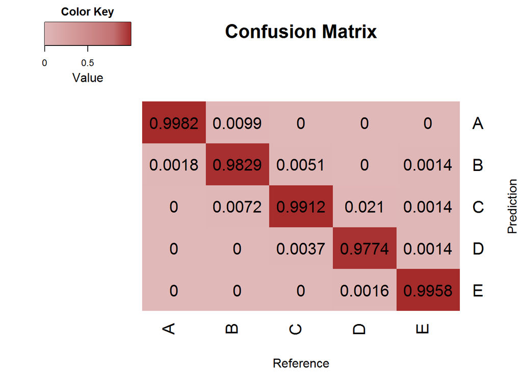

## References

- http://groupware.les.inf.puc-rio.br/har
- Velloso, E.; Bulling, A.; Gellersen, H.; Ugulino, W.; Fuks, H. Qualitative Activity Recognition of Weight Lifting Exercises. Proceedings of 4th International Conference in Cooperation with SIGCHI (Augmented Human ’13) . Stuttgart, Germany: ACM SIGCHI, 2013.